# HW3: Geospatial Risk Prediction

Jun, Youngsang

October 17, 2024

*Narcotic or Drug Law violation is the violation of laws prohibiting the cultivation, manufacture, distribution, sale, purchase, possession, transportation, importation, and/or use of certain controlled drug or narcotic substances. Narcotic drug law violations are governed by the Controlled Substances Act.*

> If a person is caught possessing narcotic drugs with the intent to sell in Schedule I, II or III it is a felony, and the person could be sentenced up to 15 years in jail and/or pay a fine of $250,000.

*Since narcotics use or drug abuse may lead to social, physical, emotional, and job-related problems, it is important to prevent relapse through treatment and education for addicts and to prevent addiction in those at risk. The Kensington area of Philadelphia is known as a major hub of narcotic crimes. This assignment applies aspects of the Broken Windows Theory to visualize drug law violations incidents and produce predictive models to forecast similar crimes in other areas of Philadelphia.*

## Crime Incidents in Philadelphia by Crime Types

From January 1, 2023 to December 31, 2023, Philadelphia recorded 161,913 crime incidents. The following graph categorizes these incidents by 31 types of crime. Of these incidents, “Narcotic/Drug Law Violations accounted for 2,551.

```r
# 2023 Crime data
philly.crime <- read.csv("https://phl.carto.com/api/v2/sql?filename=incidents_part1_part2&format=csv&q=SELECT%20*%20,%20ST_Y(the_geom)%20AS%20lat,%20ST_X(the_geom)%20AS%20lng%20FROM%20incidents_part1_part2%20WHERE%20dispatch_date_time%20%3E=%20%272023-01-01%27%20AND%20dispatch_date_time%20%3C%20%272024-01-01%27")

philly.crime <-philly.crime[!is.na(philly.crime$lat), ] %>%
    st_as_sf(coords = c("lng", "lat"), crs = 4326, agr = "constant")%>%
    st_transform('ESRI:102728') %>%
    distinct()

# Load Police Sector Data in Philadelphia
philly.policesec <- st_read("~/Public Policy/HW3/Data/phillyPoliceSector/PhiladelphiaPoliceSectorsBoundaries201202.shp") %>%
  st_as_sf(crs = 4326)%>%
  st_transform(crs = 'ESRI:102728')

# Load Police District Data in Philadelphia
philly.police <- st_read("https://opendata.arcgis.com/api/v3/datasets/62ec63afb8824a15953399b1fa819df2_0/downloads/data?format=geojson&spatialRefId=4326&where=1%3D1") %>%
  st_as_sf(crs = 4326)%>%
  st_transform(crs = 'ESRI:102728')

# Load Police Stations Data in Philadelphia
philly.policestn <- st_read("https://opendata.arcgis.com/datasets/7e522339d7c24e8ea5f2c7780291c315_0.geojson") %>%
  st_as_sf(crs = 4326)%>%
  st_transform(crs = 'ESRI:102728')

# Create Philadelphia Boundary Data
philly.boundary <- st_union(philly.police)%>%
  st_transform(crs = 'ESRI:102728')

# Load Park and Recreation Places Data in Philadelphia
philly.PPR <- st_read("https://opendata.arcgis.com/api/v3/datasets/9eb26a787a6e448ba426eea7f9f0d93a_0/downloads/data?format=geojson&spatialRefId=4326") %>%
  st_as_sf(crs = 4326)%>%
  st_transform(crs = 'ESRI:102728')
```

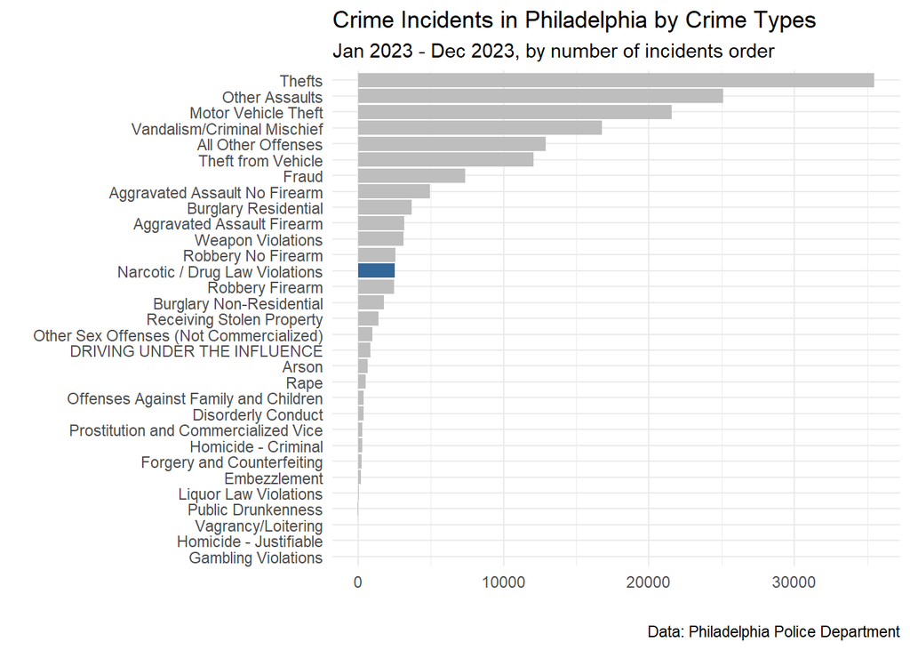

```r
ggplot(philly.crime, aes(x = fct_rev(fct_infreq(text_general_code)),
                         fill=ifelse(text_general_code == "Narcotic / Drug Law Violations" ,"Highlighted","Others"))) +
  geom_bar() +
  labs(
    title = "Crime Incidents in Philadelphia by Crime Types",
    subtitle = "Jan 2023 - Dec 2023, by number of incidents order",x="",y="",
    caption="Data: Philadelphia Police Department")+
  coord_flip() +
  scale_fill_manual(values = c("Highlighted" = "#336699", "Others" = "gray")) +
  theme_minimal() +
  theme(legend.position = "none")
```

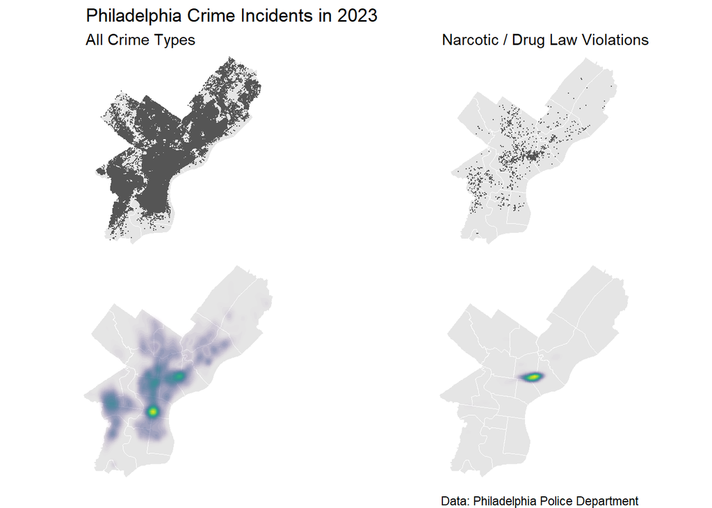

```r
crimeNarcotic <- philly.crime %>% filter(text_general_code == "Narcotic / Drug Law Violations")

# uses grid.arrange to organize independent plots
grid.arrange(ncol=2,
ggplot() +
  geom_sf(data = philly.police, color="white") +
  geom_sf(data = philly.crime, colour="#555555", size=0.1, show.legend = "point") +
  labs(title= "Philadelphia Crime Incidents in 2023",
       subtitle = "All Crime Types") +
  theme_void()+
  theme( legend.position = "none"),

ggplot() +
  geom_sf(data = philly.police, color="white") +
  geom_sf(data = crimeNarcotic, colour="#555555", size=0.1, show.legend = "point") +
  labs(title= "",
       subtitle = "Narcotic / Drug Law Violations") +
  theme_void()+
  theme( legend.position = "none"),

ggplot() +
  geom_sf(data = philly.police, color="white") +
  stat_density2d(data = data.frame(st_coordinates(philly.crime)),
                 aes(X, Y, fill = ..level.., alpha = ..level..),
                 size = 0.01, bins = 40, geom = 'polygon') +
  scale_fill_viridis(name="") +
  scale_alpha(range = c(0.00, 0.35), guide = FALSE) +
  labs(caption="") +
  theme_void()+
  theme(legend.position = "none"),

ggplot() +
  geom_sf(data = philly.police, color="white") +
  stat_density2d(data = data.frame(st_coordinates(crimeNarcotic)),
                 aes(X, Y, fill = ..level.., alpha = ..level..),
                 size = 0.01, bins = 40, geom = 'polygon') +
  scale_fill_viridis(name="") +
  scale_alpha(range = c(0.00, 0.35), guide = FALSE) +
  labs(caption = "Data: Philadelphia Police Department") +
  theme_void()+
  theme(legend.position = "none")
)
```

This assignment examines whether there is a spatial correlation between locations of Narcotic / Drug Violations incidents occurred and distance of police stations and locations of parks and public recreation places, and use this to create a predictive model. The following map shows the locations of police stations and districts, and Public Parks and Recreations (PPR) places’ locations in Philadelphia. Areas farther from police stations may give criminals a sense of being less monitored, potentially leading to a higher frequency of drug incidents. Some areas with active drug trade may be relatively close to police stations, indicating that the presence of police is not always enough to deter narcotic crimes. Parks are often large, and the view is easily obstructed by trees or structures, making it possible for discreet activities to occur. Some parks may have gaps in security during nighttime hours. This could increase the likelihood of parks being chosen as locations for Narcotics / Drugs Violations.

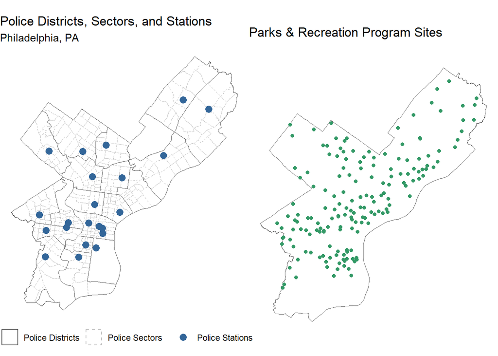

```r
# Visualize Police and Park Data
grid.arrange(ncol=2,
             ggplot()+
  geom_sf(data=philly.policesec, aes(linetype = "Police Sectors"), fill=NA, color="gray")+
  geom_sf(data=philly.police, aes(linetype = "Police Districts"), size=1, fill=NA)+
  geom_sf(data=philly.boundary, size=20, fill=NA)+
  geom_sf(data=philly.policestn, aes(color = "Police Stations"), size=3)+
  labs(
    title = "Police Districts, Sectors, and Stations",
    subtitle = "Philadelphia, PA",
    linetype = "Line Types",
    color = "Legend"
  ) +
  scale_linetype_manual(values = c("Police Districts" = "solid", "Police Sectors" = "dashed")) +
  scale_color_manual(values = c("Police Stations" = "#336699")) +
  guides(
    linetype = guide_legend(title = "",
                            override.aes = list(fill = NA)),
    color = guide_legend(title = "")
  ) +
  theme_void() +
   theme(
    legend.position = "bottom",
  ),
ggplot()+
  geom_sf(data=st_union(philly.police), size=1, fill=NA)+
  geom_sf(data=philly.PPR, color="#339966")+
  labs(
    title = "Parks & Recreation Program Sites",
    subtitle = "",
    linetype = "Line Types",
    color = "Legend"
  ) +
  guides(
    linetype = guide_legend(title = "",
                            override.aes = list(fill = NA)),
    color = guide_legend(title = "")
  ) +
  theme_void() +
   theme(
    legend.position = "bottom",
  ))
```

## Joining All Crimes and Narcotic Violation Data (Dependent Variable) to the Fishnet Grid Cells

```r
fishnet <-
  st_make_grid(philly.boundary,
               cellsize = 1000,
               square = TRUE) %>%
  .[philly.boundary] %>%            # fast way to select intersecting polygons
  st_sf() %>%
  mutate(uniqueID = 1:n())
```

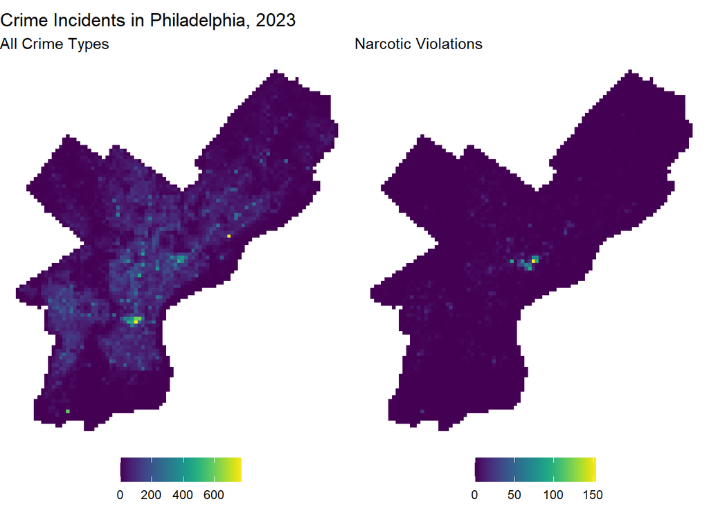

```r
crime_net <-
  dplyr::select(philly.crime) %>%
  mutate(countCrimes = 1) %>%
  aggregate(., fishnet, sum) %>%
  mutate(countCrimes = replace_na(countCrimes, 0),
         uniqueID = 1:n(),
         cvID = sample(round(nrow(fishnet) / 24),
                       size=nrow(fishnet), replace = TRUE))

crimeNar_net <-
  dplyr::select(crimeNarcotic) %>%
  mutate(countCrimes = 1) %>%
  aggregate(., fishnet, sum) %>%
  mutate(countCrimes = replace_na(countCrimes, 0),
         uniqueID = 1:n(),
         cvID = sample(round(nrow(fishnet) / 24),
                       size=nrow(fishnet), replace = TRUE))

grid.arrange(ncol=2,
ggplot() +
  geom_sf(data = crime_net, aes(fill = countCrimes), color = NA) +
  scale_fill_viridis(name = "") +
  labs(title = "Crime Incidents in Philadelphia, 2023", subtitle="All Crime Types") +
  theme_void()+
  theme(legend.position = "bottom"),
ggplot() +
  geom_sf(data = crimeNar_net, aes(fill = countCrimes), color = NA) +
  scale_fill_viridis(name = "") +
  labs(title = "", subtitle="Narcotic Violations") +
  theme_void()+
  theme(legend.position = "bottom"))
```

## Joining Risk Factors Data (Independent Variable) to the Fishnet Grid Cells

```r
philly.policestn <- philly.policestn %>%
  dplyr::select(geometry) %>%
  mutate(Legend = "Police Stations") %>%
  na.omit() %>%
  st_transform(st_crs(fishnet))

philly.PPR <- philly.PPR %>%
  dplyr::select(geometry) %>%
  mutate(Legend = "Parks & Rec") %>%
  na.omit() %>%
  st_transform(st_crs(fishnet))

neighborhoods <-
  st_read("https://raw.githubusercontent.com/blackmad/neighborhoods/master/philadelphia.geojson") %>%
  st_transform(st_crs(fishnet))

vars_net <- rbind(philly.policestn, philly.PPR) %>%
  st_join(fishnet, join=st_within) %>%
  st_drop_geometry() %>%
  group_by(uniqueID, Legend) %>%
  summarize(count = n()) %>%
  left_join(fishnet, ., by = "uniqueID") %>%
  spread(Legend, count, fill=0) %>%
  dplyr::select(-`<NA>`) %>%
  ungroup()

vars_net.long <-
  gather(vars_net, Variable, value, -geometry, -uniqueID)

vars <- unique(vars_net.long$Variable)
mapList <- list()
```

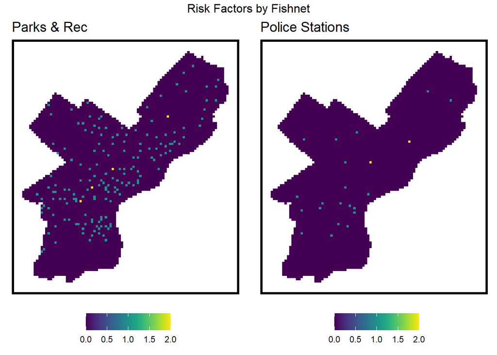

```r
for(i in vars){
  mapList[[i]] <-
    ggplot() +
      geom_sf(data = filter(vars_net.long, Variable == i),
              aes(fill = value), colour=NA) +
      scale_fill_viridis(name="") +
      labs(title=i) +
      mapTheme(title_size = 14) + theme(legend.position="bottom")}

do.call(grid.arrange, c(mapList, ncol=2, top="Risk Factors by Fishnet"))
```

## Count of Risk Factors by Grid Cell and Visualize the Nearest Neighbor (NN) Features

In this figure below, the nearest neighbor distance from police stations, public parks and recreation places is displayed in blue for closer locations, and in green and yellow for further locations.

```r
## create NN from Police Stations and Parks
vars_net <- vars_net %>%
    mutate(policeStn.nn = nn_function(st_coordinates(st_centroid(vars_net)),
                                           st_coordinates(philly.policestn),
                                           k = 3)) %>%
    mutate(PPR.nn = nn_function(st_coordinates(st_centroid(vars_net)),
                                           st_coordinates(philly.PPR),
                                           k = 3))
```

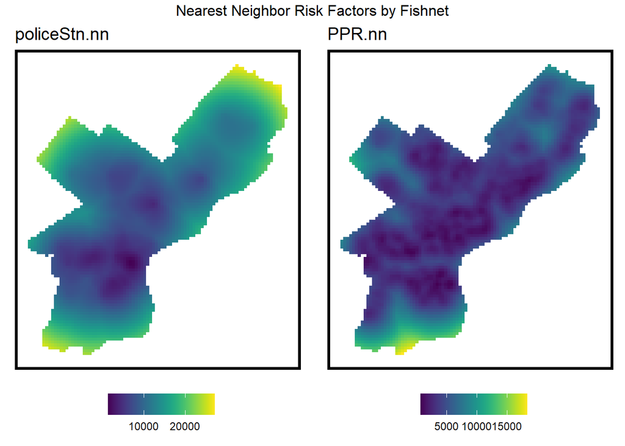

```r
vars_net.long.nn <-
  dplyr::select(vars_net, ends_with(".nn")) %>%
  gather(Variable, value, -geometry)

vars <- unique(vars_net.long.nn$Variable)
mapList <- list()

for(i in vars){
  mapList[[i]] <-
    ggplot() +
      geom_sf(data = filter(vars_net.long.nn, Variable == i),
              aes(fill = value), colour=NA) +
      scale_fill_viridis(name="") +
      labs(title=i) +
      mapTheme(title_size = 14) + theme(legend.position="bottom")}

do.call(grid.arrange, c(mapList, ncol=2, top="Nearest Neighbor Risk Factors by Fishnet"))
```

## Join NN feature to the Fishnet Grid Cells

The following fishnet-style maps are simply represents the police districts and neighborhoods in Philadelphia.

```r
## important to drop the geometry from joining features
finalNar_net <-
  left_join(crimeNar_net, st_drop_geometry(vars_net), by="uniqueID")

finalNar_net <-
  st_centroid(finalNar_net) %>%
    st_join(dplyr::select(neighborhoods, name), by = "uniqueID") %>%
    st_join(dplyr::select(philly.police, DISTRICT_), by = "uniqueID") %>%
      st_drop_geometry() %>%
      left_join(dplyr::select(finalNar_net, geometry, uniqueID)) %>%
      st_sf() %>%
    st_transform('ESRI:102728') %>%
  na.omit()
```

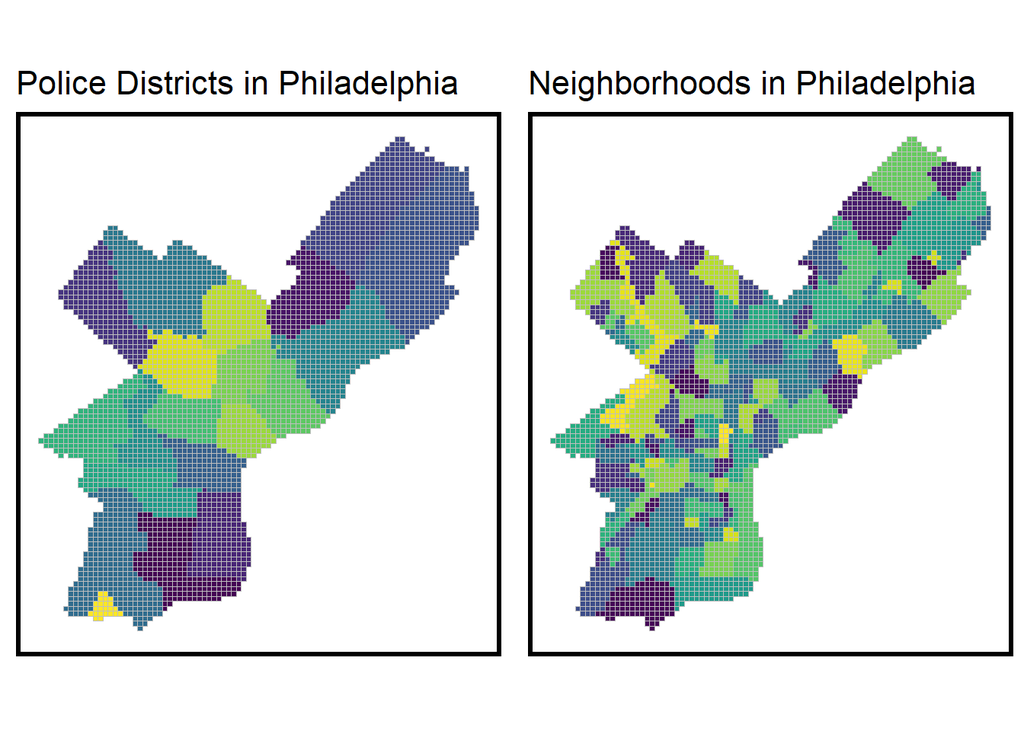

```r
grid.arrange(ncol=2,
ggplot() +
      geom_sf(data = finalNar_net, aes(fill=DISTRICT_), color="gray") +
       scale_fill_viridis_d(option = "D") +
      labs(title="Police Districts in Philadelphia") +
      mapTheme()+
      theme(legend.position = "none"),

ggplot() +
      geom_sf(data = finalNar_net, aes(fill=name), color="gray") +
       scale_fill_viridis_d(option = "D") +
      labs(title="Neighborhoods in Philadelphia") +
      mapTheme()+
      theme(legend.position = "none"))
```

## Local Moran’s I for Fishnet Grid Cells

By Local Moran’s I, I can see if cells are part of a significant cluster of high or low values, or if a cell is near a cluster. The null hypothesis for the Local Moran’s I is that the Narcotic / Drug Violations count at a given location is randomly distributed relative to its immediate neighbors, i.e. “queen” neighbors (e.g. the cells to the immediate north, south, east, west, and diagonal).

```r
## generates warnings from PROJ issues
## {spdep} to make polygon to neighborhoods...
finalNar_net.nb <- poly2nb(as_Spatial(finalNar_net), queen=TRUE)
## ... and neighborhoods to list of weigths
finalNar_net.weights <- nb2listw(finalNar_net.nb, style="W", zero.policy=TRUE)

# print(final_net.weights, zero.policy=TRUE)
```

```r
## localmoran
local_morans <- localmoran(finalNar_net$countCrimes, finalNar_net.weights, zero.policy=TRUE) %>%
  as.data.frame()

# join local Moran's I results to fishnet
finalNar_net.localMorans <-
  cbind(local_morans, as.data.frame(finalNar_net)) %>%
  st_sf() %>%
  dplyr::select(Nar_Count = countCrimes,
                Local_Morans_I = Ii,
                P_Value = `Pr(z != E(Ii))`) %>%
  mutate(Significant_Hotspots = ifelse(P_Value <= 0.001, 1, 0)) %>%
  gather(Variable, Value, -geometry)
```

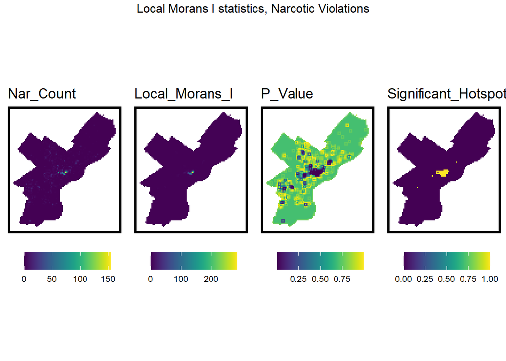

```r
## This is just for plotting
vars <- unique(finalNar_net.localMorans$Variable)
varList <- list()

for(i in vars){
  varList[[i]] <-
    ggplot() +
      geom_sf(data = filter(finalNar_net.localMorans, Variable == i),
              aes(fill = Value), colour=NA) +
      scale_fill_viridis(name="") +
      labs(title=i) +
      mapTheme(title_size = 14) + theme(legend.position="bottom")}

do.call(grid.arrange,c(varList, ncol = 4, top = "Local Morans I statistics, Narcotic Violations"))
```

The following is a graph showing the p-value levels, which shows that the hotspot p-value in the Kensington area is very small.

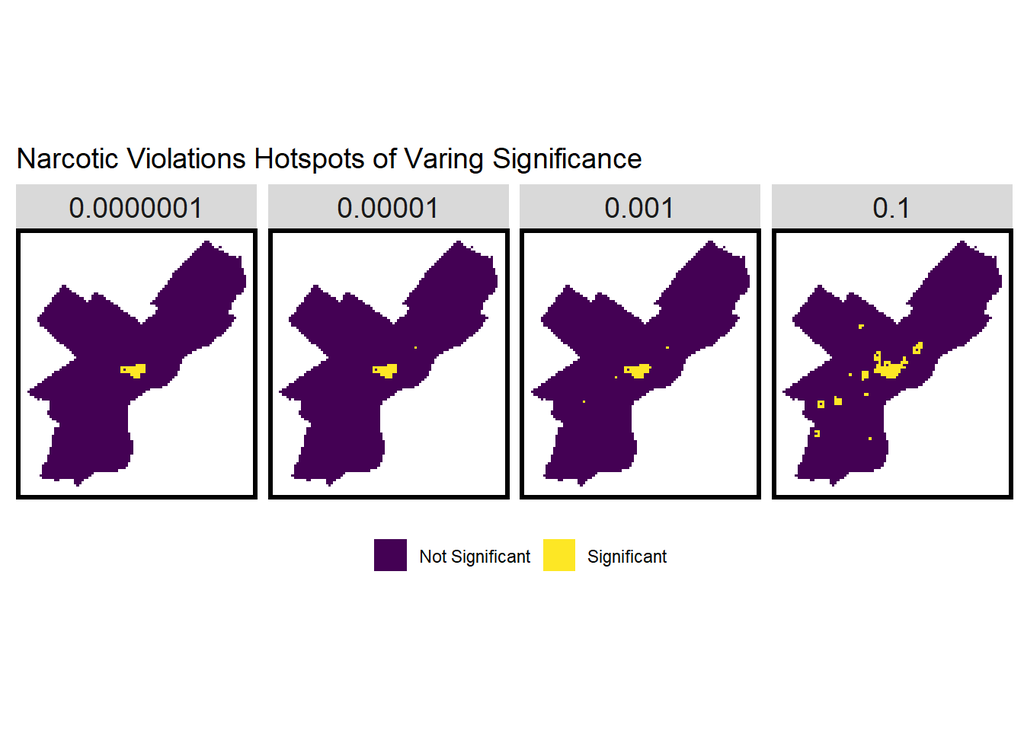

```r
## This is just for plotting
finalNar_net.localMoransbypval <-
  cbind(local_morans, as.data.frame(finalNar_net)) %>%
  st_sf() %>%
  dplyr::select(Nar_Count = countCrimes,
                Local_Morans_I = Ii,
                P_Value = `Pr(z != E(Ii))`) %>%
  mutate(Significant_Hotspots0.1 = ifelse(P_Value <= 0.1 , 1, 0)) %>%
  mutate(Significant_Hotspots0.001 = ifelse(P_Value <= 0.001 , 1, 0)) %>%
  mutate(Significant_Hotspots0.00001 = ifelse(P_Value <= 0.00001 , 1, 0)) %>%
  mutate(Significant_Hotspots0.0000001 = ifelse(P_Value <= 0.0000001, 1, 0)) %>%
  gather(Variable, Value, -geometry)

finalNar_net.localMoransbypval <- subset(finalNar_net.localMoransbypval, grepl("Significant_Hotspots", Variable))
finalNar_net.localMoransbypval$Value <- factor(finalNar_net.localMoransbypval$Value)
custom_labels <- c("Significant_Hotspots0.1" = "0.1",
                   "Significant_Hotspots0.001" = "0.001",
                   "Significant_Hotspots0.00001" = "0.00001",
                   "Significant_Hotspots0.0000001" = "0.0000001")
custom_legend <- c("0" = "Not Significant", "1" = "Significant")
ggplot() +
      geom_sf(data = finalNar_net.localMoransbypval,
              aes(fill = Value), colour=NA) +
      scale_fill_viridis_d(labels = custom_legend, name="") +
      labs(title="Narcotic Violations Hotspots of Varing Significance") +
      facet_wrap(~Variable, ncol=4, labeller = labeller(Variable = custom_labels))+
      mapTheme(title_size = 14) + theme(legend.position="bottom")
```

## Measuring Nearest Neighbor Distance to Hotspot

```r
# generates warning from NN
finalNar_net <- finalNar_net %>%
  mutate(narcotic.isSig =
           ifelse(local_morans[,5] <= 0.001, 1, 0)) %>%
  mutate(narcotic.isSig.dist =
           nn_function(st_coordinates(st_centroid(finalNar_net)),
                       st_coordinates(st_centroid(filter(finalNar_net,
                                           narcotic.isSig == 1))),
                       k = 1)) %>%
  mutate(narcotic.isSig.distmile =
           narcotic.isSig.dist/5280)
```

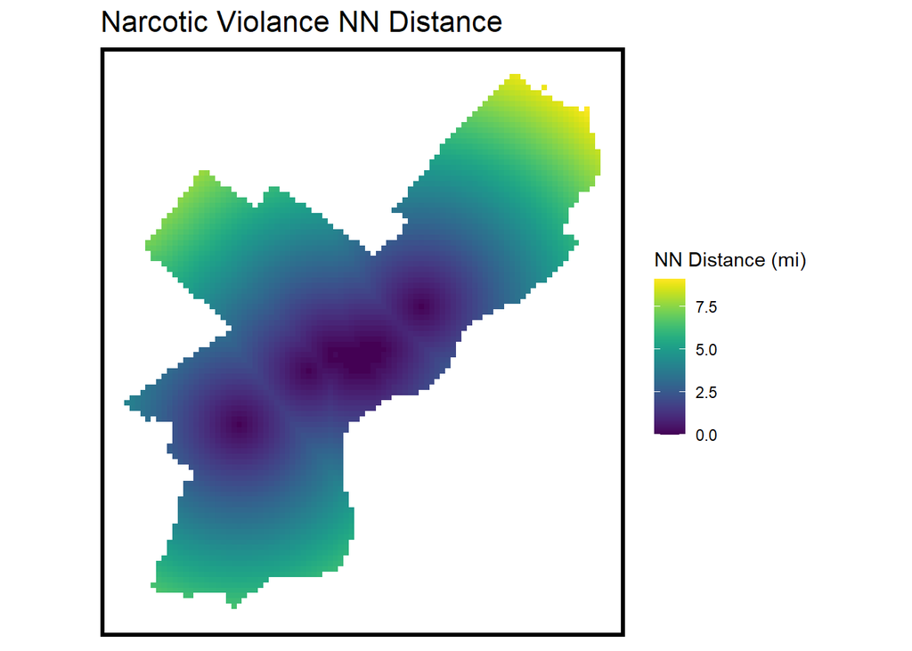

```r
ggplot() +
      geom_sf(data = finalNar_net, aes(fill=narcotic.isSig.distmile), colour=NA) +
      scale_fill_viridis(name="NN Distance (mi)") +
      labs(title="Narcotic Violance NN Distance") +
      mapTheme()
```

The following six plots show count and nearest neighbor correlations side-by-side.

```r
correlation.long <-
  st_drop_geometry(finalNar_net) %>%
    dplyr::select(-uniqueID, -cvID, -name, -DISTRICT_, -narcotic.isSig.distmile) %>%
    gather(Variable, Value, -countCrimes)

correlation.cor <-
  correlation.long %>%
  group_by(Variable) %>%
  summarize(correlation = cor(Value, countCrimes, use = "complete.obs"))
```

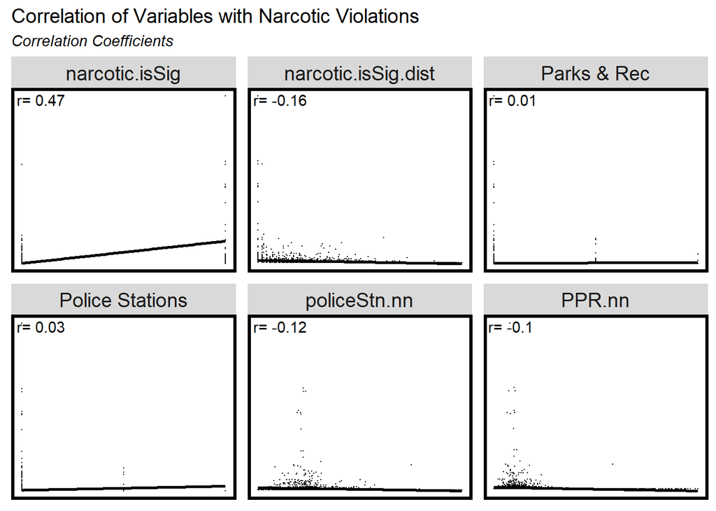

```r
ggplot(correlation.long, aes(Value, countCrimes)) +
  geom_point(size=0.1) +
  geom_text(data=correlation.cor, aes(label=paste("r=", round(correlation, 2))),
            x=-Inf, y=Inf, vjust=1.5, hjust=-.1) +
  geom_smooth(method = "lm", se = FALSE, color="black") +
  facet_wrap(~Variable, ncol=3, scales = "free") +
  labs(title="Correlation of Variables with Narcotic Violations",
       subtitle="Correlation Coefficients",
       x="Value", y="Narcotic Violations") +
  mapTheme(title_size = 14)
```

## Modeling and Cross-Validation

In this section, Leave One Group Out (LOGO) spatial CV on these spatial features performed using only nearest neighbor, and distance to cluster variables. Since geospatial risk models are purely spatial, spatial cross-validation is an important option. LOGO is to hold-out one local area, train the model on the remaining n-1 areas, predict for the hold-out, and record the goodness of fit.

`crossValidate` takes a `dataset`, a dependent variable `dependentVariable` (`countCrimes`), a list of independent variables (`reg.ss.vars`) , and an `id` - which is a cross validation category.

```r
# View(crossValidate)

reg.vars <- c("policeStn.nn","PPR.nn")
## define the variables we want
reg.ss.vars <- c("policeStn.nn","PPR.nn","narcotic.isSig","narcotic.isSig.dist")

## RUN REGRESSIONS
reg.CV <- crossValidate(
  dataset = finalNar_net,
  id = "cvID",
  dependentVariable = "countCrimes",
  indVariables = reg.vars) %>%
    dplyr::select(cvID = cvID, countCrimes, Prediction, geometry)

reg.ss.CV <- crossValidate(
  dataset = finalNar_net,
  id = "cvID",
  dependentVariable = "countCrimes",
  indVariables = reg.ss.vars) %>%
    dplyr::select(cvID = cvID, countCrimes, Prediction, geometry)

## LOGO CV
reg.spatialCV <- crossValidate(
  dataset = finalNar_net,
  id = "name",
  dependentVariable = "countCrimes",
  indVariables = reg.vars) %>%
    dplyr::select(cvID = name, countCrimes, Prediction, geometry)

reg.ss.spatialCV <- crossValidate(
  dataset = finalNar_net,
  id = "name",
  dependentVariable = "countCrimes",
  indVariables = reg.ss.vars) %>%
    dplyr::select(cvID = name, countCrimes, Prediction, geometry)

reg.summary <-
  rbind(
    mutate(reg.CV,
           Error = Prediction - countCrimes,
           Regression = "Random k-fold CV: Just Risk Factors"),
    mutate(reg.ss.CV,
           Error = Prediction - countCrimes,
           Regression = "Random k-fold CV: Spatial Process"),
    mutate(reg.spatialCV,
           Error = Prediction - countCrimes,
           Regression = "Spatial LOGO-CV: Just Risk Factors"),
    mutate(reg.ss.spatialCV,
           Error = Prediction - countCrimes,
           Regression = "Spatial LOGO-CV: Spatial Process")
  ) %>%
  st_sf()
```

The following results show the calculated errors across space, by four different methods. This result confirms the conclusion that the spatial process features improve the model, since the counts with small MAEs slightly increased in each spatial process, and the mean MAE value slightly decreased.

```r
# calculate errors by NEIGHBORHOOD
error_by_reg_and_fold <-
  reg.summary %>%
    group_by(Regression, cvID) %>%
    summarize(Mean_Error = mean(Prediction - countCrimes, na.rm = T),
              MAE = mean(abs(Mean_Error), na.rm = T),
              SD_MAE = mean(abs(Mean_Error), na.rm = T)) %>%
  ungroup()

error_by_reg_and_fold %>%
  arrange(desc(MAE))
error_by_reg_and_fold %>%
  arrange(MAE)
```

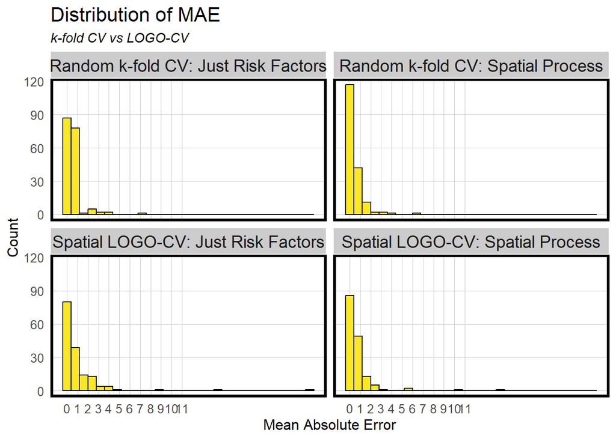

```r
## plot histogram of OOF (out of fold) errors
error_by_reg_and_fold %>%
  ggplot(aes(MAE)) +
    geom_histogram(bins = 30, colour="black", fill = "#FDE725FF") +
    facet_wrap(~Regression) +
    scale_x_continuous(breaks = seq(0, 11, by = 1)) +
    labs(title="Distribution of MAE", subtitle = "k-fold CV vs LOGO-CV",
         x="Mean Absolute Error", y="Count") +
    plotTheme()
```

```r
st_drop_geometry(error_by_reg_and_fold) %>%
  group_by(Regression) %>%
  summarize(Mean_MAE = round(mean(MAE),2),
            SD_MAE = round(sd(MAE), 2)) %>%
  kable() %>%
    kable_styling("striped", full_width = F) %>%
    row_spec(2, color="black", background="yellow") %>%
    row_spec(4, color="black", background="yellow")
```

| Regression | Mean_MAE | SD_MAE |
| --- | --- | --- |
| Random k-fold CV: Just Risk Factors | 0.56 | 0.81 |
| Random k-fold CV: Spatial Process | 0.53 | 0.73 |
| Spatial LOGO-CV: Just Risk Factors | 1.10 | 2.37 |
| Spatial LOGO-CV: Spatial Process | 0.74 | 1.56 |

The following map visualizes the LOGO-CV errors spatially. In other cases, these kinds of maps can visualize where the higher errors occur when the local spatial process is not accounted for. In this case, however, it was not known whether the higher errors occur when the local spatial process is not accounted for because the hotspots were concentrated in a specific area (Kensington area) and the remaining areas did not have a large difference in value. However, it was confirmed that the MAE value of the hotspots slightly decreased.

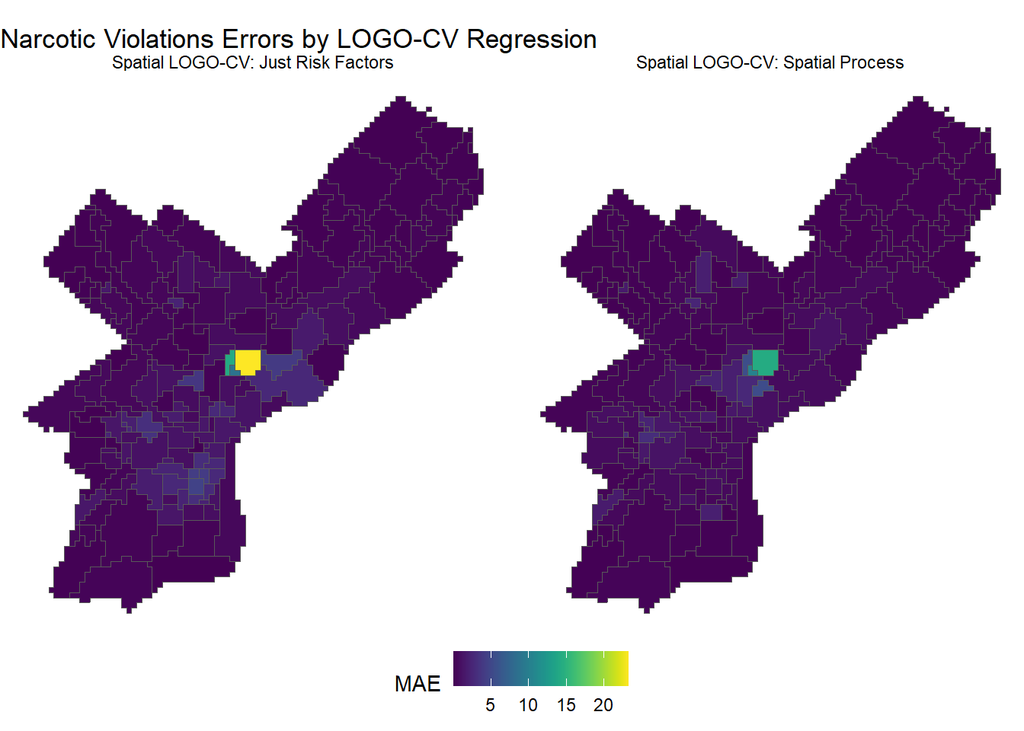

```r
error_by_reg_and_fold %>%
  filter(str_detect(Regression, "LOGO")) %>%
  ggplot() +
    geom_sf(aes(fill=MAE)) +
    facet_wrap(~Regression) +
    scale_fill_viridis()+
    labs(title="Narcotic Violations Errors by LOGO-CV Regression")+
    theme_void() +
    theme(legend.position = "bottom")
```

The following three figures are maps comparing observed, predicted (just risk factors), and predicted (with spatial process). The predicted are much smoother than the observed, and there is little difference between predicted (just risk factors) and predicted (with spatial process) on the maps.

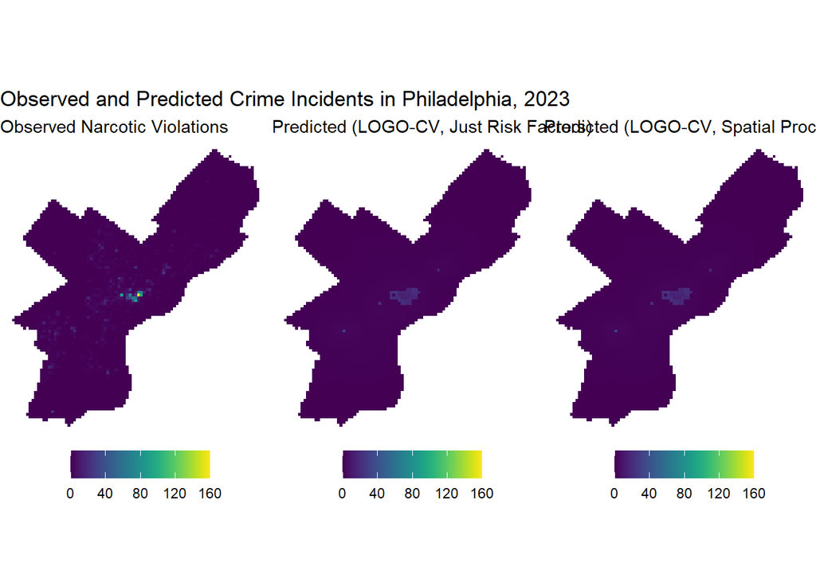

```r
grid.arrange(ncol=3,

ggplot(reg.CV) +
  geom_sf(aes(fill = countCrimes), color = NA) +
  scale_fill_viridis(name = "", limits=c(0,160)) +
  labs(title = "Observed and Predicted Crime Incidents in Philadelphia, 2023", subtitle="Observed Narcotic Violations") +
  theme_void()+
  theme(legend.position = "bottom"),
ggplot(reg.spatialCV) +
  geom_sf(data = reg.summary, aes(fill = Prediction), color = NA) +
  scale_fill_viridis(name = "", limits=c(0,160)) +
  labs(title = "", subtitle="Predicted (LOGO-CV, Just Risk Factors)") +
  theme_void()+
  theme(legend.position = "bottom"),
ggplot(reg.ss.spatialCV) +
  geom_sf(data = reg.summary, aes(fill = Prediction), color = NA) +
  scale_fill_viridis(name = "", limits=c(0,160)) +
  labs(title = "", subtitle="Predicted (LOGO-CV, Spatial Process)") +
  theme_void()+
  theme(legend.position = "bottom")
)
```

## Kernel Density vs predictions

By Kernel Density estimates (e.g. a hotspot map), the predictions to across-time generalizability comparison is possible. The following map shows three kernel density maps at three different scales.

```r
# demo of kernel width
crime_ppp <- as.ppp(st_coordinates(crimeNarcotic), W = st_bbox(finalNar_net))
crime_KD.1000 <- spatstat.explore::density.ppp(crime_ppp, 1000)
crime_KD.1500 <- spatstat.explore::density.ppp(crime_ppp, 1500)
crime_KD.2000 <- spatstat.explore::density.ppp(crime_ppp, 2000)
crime_KD.df <- rbind(
  mutate(data.frame(rasterToPoints(mask(raster(crime_KD.1000), as(neighborhoods, 'Spatial')))), Legend = "1000 Ft."),
  mutate(data.frame(rasterToPoints(mask(raster(crime_KD.1500), as(neighborhoods, 'Spatial')))), Legend = "1500 Ft."),
  mutate(data.frame(rasterToPoints(mask(raster(crime_KD.2000), as(neighborhoods, 'Spatial')))), Legend = "2000 Ft."))

crime_KD.df$Legend <- factor(crime_KD.df$Legend, levels = c("1000 Ft.", "1500 Ft.", "2000 Ft."))
```

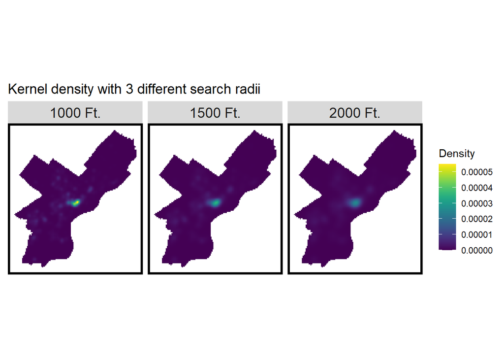

```r
ggplot(data=crime_KD.df, aes(x=x, y=y)) +
  geom_raster(aes(fill=layer)) +
  facet_wrap(~Legend) +
  coord_sf(crs=st_crs(finalNar_net)) +
  scale_fill_viridis(name="Density") +
  labs(title = "Kernel density with 3 different search radii") +
  mapTheme(title_size = 14)
```

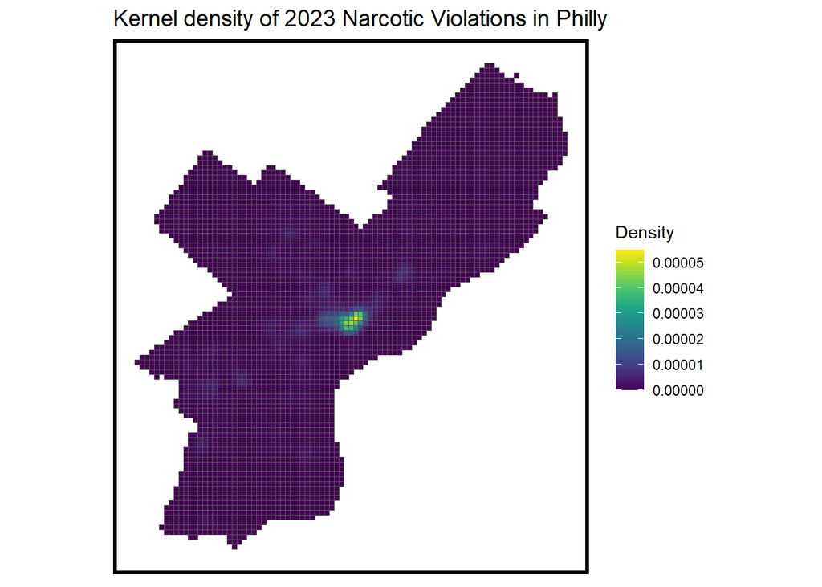

```r
as.data.frame(crime_KD.1000) %>%
  st_as_sf(coords = c("x", "y"), crs = st_crs(finalNar_net)) %>%
  aggregate(., finalNar_net, mean) %>%
   ggplot() +
     geom_sf(aes(fill=value)) +
#     geom_sf(data = sample_n(philly.crime, 1500), size = .5) +
     scale_fill_viridis(name = "Density") +
     labs(title = "Kernel density of 2023 Narcotic Violations in Philly") +
     mapTheme(title_size = 14)
```

## Comparing 2023 Narcotic Violations Incidents with 2024

In this section, it can be defined whether the 2023 model forecast above predicts better than a kernel density estimate on 2023 data for the following year (2024) incidents.

```r
crimeNarcotic24 <- read.csv("https://phl.carto.com/api/v2/sql?filename=incidents_part1_part2&format=csv&q=SELECT%20*%20,%20ST_Y(the_geom)%20AS%20lat,%20ST_X(the_geom)%20AS%20lng%20FROM%20incidents_part1_part2%20WHERE%20dispatch_date_time%20%3E=%20%272024-01-01%27%20AND%20dispatch_date_time%20%3C%20%272025-01-01%27") %>%
  filter(text_general_code == "Narcotic / Drug Law Violations"
         ) # 2024 Narcotic Violations Crime data

crimeNarcotic24 <- subset(crimeNarcotic24, the_geom!='0101000020E6100000A5A31CCC262054C0A8BE77C4B61C4540') #error
crimeNarcotic24 <- subset(crimeNarcotic24, the_geom!='0101000020E6100000E3D840DB262054C0CCE8EC09B71C4540') #error

crimeNarcotic24 <-crimeNarcotic24[!is.na(crimeNarcotic24$lat), ] %>%
    st_as_sf(coords = c("lng", "lat"), crs = 4326, agr = "constant")%>%
    st_transform('ESRI:102728') %>%
    distinct() %>%
  .[fishnet,]
```

```r
crime_KDE_sum <- as.data.frame(crime_KD.1000) %>%
  st_as_sf(coords = c("x", "y"), crs = st_crs(finalNar_net)) %>%
  aggregate(., finalNar_net, mean)

kde_breaks <- classIntervals(crime_KDE_sum$value,
                             n = 5, "fisher")

crime_KDE_sf <- crime_KDE_sum %>%
  mutate(label = "Kernel Density",
         Risk_Category = classInt::findCols(kde_breaks),
         Risk_Category = case_when(
           Risk_Category == 5 ~ "5th",
           Risk_Category == 4 ~ "4th",
           Risk_Category == 3 ~ "3rd",
           Risk_Category == 2 ~ "2nd",
           Risk_Category == 1 ~ "1st")) %>%
  cbind(
    aggregate(
      dplyr::select(crimeNarcotic24) %>% mutate(countCrimes = 1), ., sum) %>%
    mutate(countCrimes = replace_na(countCrimes, 0))) %>%
  dplyr::select(label, Risk_Category, countCrimes)
```

```r
ml_breaks <- classIntervals(reg.ss.spatialCV$Prediction,
                             n = 5, "fisher")
crime_risk_sf <-
  reg.ss.spatialCV %>%
  mutate(label = "Risk Predictions",
         Risk_Category =classInt::findCols(ml_breaks),
         Risk_Category = case_when(
           Risk_Category == 5 ~ "5th",
           Risk_Category == 4 ~ "4th",
           Risk_Category == 3 ~ "3rd",
           Risk_Category == 2 ~ "2nd",
           Risk_Category == 1 ~ "1st")) %>%
  cbind(
    aggregate(
      dplyr::select(crimeNarcotic24) %>% mutate(countCrimes = 1), ., sum) %>%
      mutate(countCrimes  = replace_na(countCrimes , 0))) %>%
  dplyr::select(label,Risk_Category, countCrimes )
```

As a result in the following maps, the risk prediction model tended to appear smooth. This tend can be confirmed in the next plots.

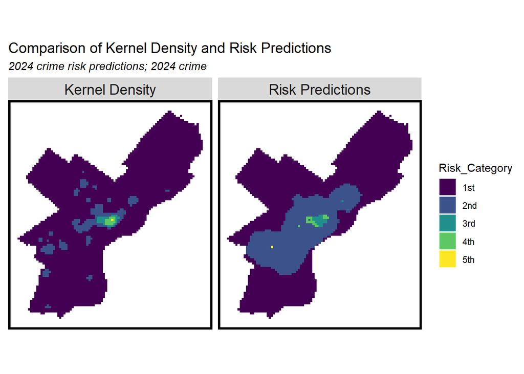

```r
rbind(crime_KDE_sf, crime_risk_sf) %>%
  na.omit() %>%
  gather(Variable, Value, -label, -Risk_Category, -geometry) %>%
  ggplot() +
    geom_sf(aes(fill = Risk_Category), colour = NA) +
 #   geom_sf(data = sample_n(philly.crime24, 2000), size = .5, colour = "black") +
    facet_wrap(~label, ) +
    scale_fill_viridis(discrete = TRUE) +
    labs(title="Comparison of Kernel Density and Risk Predictions",
         subtitle="2024 crime risk predictions; 2024 crime") +
    mapTheme(title_size = 14)
```

In addition, in the risk prediction model in the following plots, the 2nd and 3rd were over-estimated, and the 4th and 5th were under-estimated compared to the KD model. However, on the contrary, a well-fit model should show that the risk prediction captures a greater share of 2024 in the highest risk category relative to the kernel density.

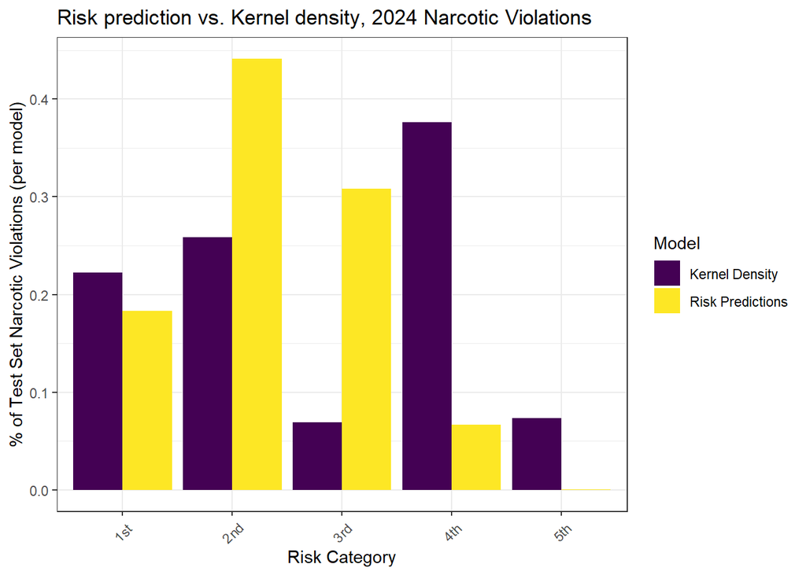

```r
rbind(crime_KDE_sf, crime_risk_sf) %>%
  st_drop_geometry() %>%
  na.omit() %>%
  gather(Variable, Value, -label, -Risk_Category) %>%
  group_by(label, Risk_Category) %>%
  summarize(countCrimes = sum(Value)) %>%
  ungroup() %>%
  group_by(label) %>%
  mutate(Pcnt_of_test_set_crimes = countCrimes / sum(countCrimes)) %>%
    ggplot(aes(Risk_Category,Pcnt_of_test_set_crimes)) +
      geom_bar(aes(fill=label), position="dodge", stat="identity") +
      scale_fill_viridis(discrete = TRUE, name = "Model") +
      labs(title = "Risk prediction vs. Kernel density, 2024 Narcotic Violations",
           y = "% of Test Set Narcotic Violations (per model)",
           x = "Risk Category") +
  theme_bw() +
      theme(axis.text.x = element_text(angle = 45, vjust = 0.5))
```

## Conclusions and Discussion

In this assignment, a geospatial risk model for Narcotics / Drugs Crimes in Philadelphia in 2023 was produced based on the locations of police stations and public parks and recreation places, as well as LOGO cross-validation and kernel density analysis for the model, and comparison with application to the 2024 data. The analysis revealed that the Kensington area formed a significant hotspot for narcotic crimes. However, it was unclear how much the locations of police stations and parks contributed to the model, likely because the narcotic violations data in Philadelphia were concentrated in one area known as Kensington. For the same reason, it was difficult to predict the future spatial spread of drug-related crimes based on the Broken Windows Theory. In the future, given the importance of crime prevention, a spatial analysis approach with the efforts to incorporate additional factors such as police patrol routes, ports, airports, major roads, and traffic information must be necessary.

## References:

https://www.pasda.psu.edu/uci/DataSummary.aspx?dataset=1028

https://github.com/blackmad/neighborhoods